# Project Python Foundations: FoodHub Data Analysis

### Context

The number of restaurants in New York is increasing day by day. Lots of students and busy professionals rely on those restaurants due to their hectic lifestyles. Online food delivery service is a great option for them. It provides them with good food from their favorite restaurants. A food aggregator company FoodHub offers access to multiple restaurants through a single smartphone app.

The app allows the restaurants to receive a direct online order from a customer. The app assigns a delivery person from the company to pick up the order after it is confirmed by the restaurant. The delivery person then uses the map to reach the restaurant and waits for the food package. Once the food package is handed over to the delivery person, he/she confirms the pick-up in the app and travels to the customer's location to deliver the food. The delivery person confirms the drop-off in the app after delivering the food package to the customer. The customer can rate the order in the app. The food aggregator earns money by collecting a fixed margin of the delivery order from the restaurants.

### Objective

The food aggregator company has stored the data of the different orders made by the registered customers in their online portal. They want to analyze the data to get a fair idea about the demand of different restaurants which will help them in enhancing their customer experience. Suppose you are hired as a Data Scientist in this company and the Data Science team has shared some of the key questions that need to be answered. Perform the data analysis to find answers to these questions that will help the company to improve the business.

### Data Description

The data contains the different data related to a food order. The detailed data dictionary is given below.

### Data Dictionary

- order_id: Unique ID of the order
- customer_id: ID of the customer who ordered the food
- restaurant_name: Name of the restaurant
- cuisine_type: Cuisine ordered by the customer
- cost_of_the_order: Cost of the order
- day_of_the_week: Indicates whether the order is placed on a weekday or weekend (The weekday is from Monday to Friday and the weekend is Saturday and Sunday)
- rating: Rating given by the customer out of 5
- food_preparation_time: Time (in minutes) taken by the restaurant to prepare the food. This is calculated by taking the difference between the timestamps of the restaurant's order confirmation and the delivery person's pick-up confirmation.
- delivery_time: Time (in minutes) taken by the delivery person to deliver the food package. This is calculated by taking the difference between the timestamps of the delivery person's pick-up confirmation and drop-off information

### Let us start by importing the required libraries

```python
# Install specific versions of the libraries
!pip install -q numpy==1.25.2 pandas==1.5.3 matplotlib==3.7.1 seaborn==0.13.1
```

[output not shown]

**Note**:

- After running the above cell, kindly restart the runtime (for Google Colab) or notebook kernel (for Jupyter Notebook), and run all cells sequentially from the next cell.
- On executing the above line of code, you might see a warning regarding package dependencies. This error message can be ignored as the above code ensures that all necessary libraries and their dependencies are maintained to successfully execute the code in *this notebook*.

```python
import numpy as np
import pandas as pd
import matplotlib.pyplot as plt
import seaborn as sns
```

Why These Libraries Are Used

1. import numpy as np

NumPy is the foundational library for numerical computing in Python. In this project, it helps because:

The dataset contains numerical variables (e.g., cost_of_the_order, food_preparation_time, delivery_time, rating).

NumPy provides fast mathematical operations for calculations, aggregations, and statistical summaries.

Many functions in pandas, seaborn, and matplotlib rely internally on NumPy arrays.

In short: NumPy ensures efficient handling of large amounts of numerical data, making analysis faster and more reliable.

1. import pandas as pd

Pandas is the main tool for data manipulation and analysis.

We use Pandas in this FoodHub project because:

The dataset is in CSV format → pd.read_csv() loads it easily.

It allows us to explore and clean data (e.g., .info(), .describe(), .isnull()).

Grouping and aggregating operations (like mean delivery time on weekdays vs weekends) are done using Pandas.

It supports filtering, selecting columns, and merging datasets.

In short: Pandas is essential for preparing, cleaning, and analyzing the FoodHub order data.

1. import matplotlib.pyplot as plt

Matplotlib is a plotting library used to create visual graphs.

In this project, it helps because:

We need to visualise patterns such as delivery time distributions, ratings, cost of orders, etc.

Matplotlib provides the basic structure for creating charts like bar graphs, histograms, and scatterplots.

Seaborn (below) is built on top of matplotlib, so matplotlib is required even if most charts come from seaborn.

In short: Matplotlib is used to create and customise visualisations to support your analysis.

1. import seaborn as sns

Seaborn sits on top of matplotlib and is great for statistical visualisation.

Why we use it for FoodHub:

It creates more attractive, easy-to-read charts with minimal code.

It is ideal for multivariate analysis, which your assignment requires (e.g., joint plots, heatmaps, boxplots).

It helps reveal relationships between variables like:

cost vs. rating

cuisine type vs. delivery time

preparation time vs. delivery time

It also handles categorical variables beautifully.

In short: Seaborn helps create professional and intuitive statistical charts, making patterns clearer for business recommendation insights.

### Understanding the structure of the data

```python
# uncomment and run the below code snippets if the dataset is present in the Google Drive
# from google.colab import drive
# drive.mount('/content/drive')
```

```python
from google.colab import files
uploaded = files.upload()
```

Upload widget is only available when the cell has been executed in the current browser session. Please rerun this cell to enable.

```
Saving foodhub_order.csv to foodhub_order.csv
```

```python
import pandas as pd
df = pd.read_csv('foodhub_order.csv', encoding='latin1')
df.head()
```

|  | order_id | customer_id | restaurant_name | cuisine_type | cost_of_the_order | day_of_the_week | rating | food_preparation_time | delivery_time |
| --- | --- | --- | --- | --- | --- | --- | --- | --- | --- |
| 0 | 1477147 | 337525 | Hangawi | Korean | 30.75 | Weekend | Not given | 25 | 20 |
| 1 | 1477685 | 358141 | Blue Ribbon Sushi Izakaya | Japanese | 12.08 | Weekend | Not given | 25 | 23 |
| 2 | 1477070 | 66393 | Cafe Habana | Mexican | 12.23 | Weekday | 5 | 23 | 28 |
| 3 | 1477334 | 106968 | Blue Ribbon Fried Chicken | American | 29.20 | Weekend | 3 | 25 | 15 |
| 4 | 1478249 | 76942 | Dirty Bird to Go | American | 11.59 | Weekday | 4 | 25 | 24 |

The code first imports the Pandas library, which is essential for working with tabular data. The read_csv() function is then used to load the FoodHub order dataset into a DataFrame named df, using latin1 encoding to correctly read any special characters in the file. Finally, df.head() displays the first few rows of the dataset, allowing us to quickly inspect the structure, column names, and sample data before proceeding with further analysis.

```python
# Write your code here to view the first 5 rows
```

```python
# Returns the first 5 rows
df.head()
```

|  | order_id | customer_id | restaurant_name | cuisine_type | cost_of_the_order | day_of_the_week | rating | food_preparation_time | delivery_time |
| --- | --- | --- | --- | --- | --- | --- | --- | --- | --- |
| 0 | 1477147 | 337525 | Hangawi | Korean | 30.75 | Weekend | Not given | 25 | 20 |
| 1 | 1477685 | 358141 | Blue Ribbon Sushi Izakaya | Japanese | 12.08 | Weekend | Not given | 25 | 23 |
| 2 | 1477070 | 66393 | Cafe Habana | Mexican | 12.23 | Weekday | 5 | 23 | 28 |
| 3 | 1477334 | 106968 | Blue Ribbon Fried Chicken | American | 29.20 | Weekend | 3 | 25 | 15 |
| 4 | 1478249 | 76942 | Dirty Bird to Go | American | 11.59 | Weekday | 4 | 25 | 24 |

This code is used to preview the dataset after loading it into Python. The df.head() function displays the first five rows of the DataFrame, allowing us to quickly inspect the structure of the data, verify that the file was loaded correctly, and understand the types of values in each column. This is an essential first step in exploratory data analysis before performing any further cleaning or analysis.

### **Question 1:** How many rows and columns are present in the data? [0.5 mark]

```python
# Check the shape of the dataset
df.shape
```

```
(1898, 9)
```

#### Observations:

Why this code is used

The line df.shape is used to check the overall size of the dataset. It returns a tuple in the form (number of rows, number of columns). This helps us understand how many records (orders) are available for analysis and how many variables (features) each record contains. Knowing the dataset’s dimensions is one of the first steps in exploratory data analysis because it tells us how much data we are working with and whether the dataset is sufficiently large for meaningful insights.

Observation

The output (1898, 9) shows that the FoodHub dataset contains 1,898 rows and 9 columns. This means there are 1,898 individual food orders recorded, each described by 9 attributes such as customer ID, restaurant name, cuisine type, order cost, preparation time, and delivery time. The dataset is sufficiently large to perform reliable statistical analysis and draw business insights.

### **Question 2:** What are the datatypes of the different columns in the dataset? (The info() function can be used) [0.5 mark]

```python
df.info()
```

```
<class 'pandas.core.frame.DataFrame'>
RangeIndex: 1898 entries, 0 to 1897
Data columns (total 9 columns):
 #   Column                 Non-Null Count  Dtype
---  ------                 --------------  -----
 0   order_id               1898 non-null   int64
 1   customer_id            1898 non-null   int64
 2   restaurant_name        1898 non-null   object
 3   cuisine_type           1898 non-null   object
 4   cost_of_the_order      1898 non-null   float64
 5   day_of_the_week        1898 non-null   object
 6   rating                 1898 non-null   object
 7   food_preparation_time  1898 non-null   int64
 8   delivery_time          1898 non-null   int64
dtypes: float64(1), int64(4), object(4)
memory usage: 133.6+ KB
```

#### Observations:

The df.info() function is used to get a quick summary of the dataset, including the data types, number of non-null values, and memory usage. Qualitatively, this helps us understand the structure and quality of the data before deeper analysis. Quantitatively, it shows exactly how many valid entries each column contains (in this case, all 1,898 rows are complete), and identifies which columns are numerical (int64, float64) versus categorical (object). This information is essential because different types of analyses require different data types—e.g., numerical columns can be used for statistical calculations, while categorical columns are used for grouping and segmentation.

✅ Observation

The dataset contains 1,898 rows and 9 columns, and all columns have no missing values, which means the dataset is complete and ready for analysis. The columns order_id, customer_id, food_preparation_time, and delivery_time are stored as integers, while cost_of_the_order is a float, indicating continuous numerical values. The variables restaurant_name, cuisine_type, day_of_the_week, and rating are stored as object (string) types, which is appropriate for categorical information. This mixture of numerical and categorical data allows for a wide range of statistical and visual analyses, such as comparing preparation time across cuisines or examining delivery time differences between weekdays and weekends.

### **Question 3:** Are there any missing values in the data? If yes, treat them using an appropriate method. [1 mark]

```python
# Check missing values
df.isnull().sum()

# Treat missing values
df.fillna(df.median(numeric_only=True), inplace=True)
df.fillna(df.mode().iloc[0], inplace=True)

# Verify again
df.isnull().sum()
```

|  | 0 |
| --- | --- |
| order_id | 0 |
| customer_id | 0 |
| restaurant_name | 0 |
| cuisine_type | 0 |
| cost_of_the_order | 0 |
| day_of_the_week | 0 |
| rating | 0 |
| food_preparation_time | 0 |
| delivery_time | 0 |

**dtype:** int64

#### Observations:

This code is used to identify and handle missing values in the dataset. Qualitatively, checking for missing values is an essential part of data cleaning because incomplete data can lead to inaccurate insights and biased analysis. Quantitatively, the function df.isnull().sum() returns the total number of missing entries in each column, helping us determine whether any data needs imputation.

The next two lines of code apply appropriate treatment methods:

Median imputation for numerical columns (numeric_only=True) to avoid distortion caused by extreme values.

Mode imputation for categorical columns, replacing missing entries with the most frequent category.

After treatment, df.isnull().sum() is run again to verify that all missing values have been successfully addressed.

✅ Observation

The output shows that all columns have zero missing values, meaning the dataset is fully complete. This indicates that each of the 1,898 orders contains valid information for every variable (order details, cuisine type, preparation time, delivery time, etc.). Since no column contains missing entries, no imputation was actually required. This clean and complete dataset allows us to proceed confidently with analysis, modelling, and visualization without concerns about data loss or bias caused by missing values.

### **Question 4:** Check the statistical summary of the data. What is the minimum, average, and maximum time it takes for food to be prepared once an order is placed? [2 marks]

```python
min_time = df['food_preparation_time'].min()
avg_time = df['food_preparation_time'].mean()
max_time = df['food_preparation_time'].max()

min_time, avg_time, max_time
print("Minimum preparation time :", df['food_preparation_time'].min(), "minutes")
print("Average preparation time :", df['food_preparation_time'].mean(), "minutes")
print("Maximum preparation time :", df['food_preparation_time'].max(), "minutes")
```

```
Minimum preparation time : 20 minutes
Average preparation time : 27.371970495258168 minutes
Maximum preparation time : 35 minutes
```

#### Observations:

his code is used to calculate key statistical measures — minimum, average (mean), and maximum — for the food_preparation_time column. Qualitatively, these metrics help us understand the overall efficiency of restaurants in preparing food. Quantitatively, the .min(), .mean(), and .max() functions return exact numerical values that summarize the distribution of preparation times. These values allow the company to benchmark performance, identify slow or fast restaurants, and evaluate whether customers are likely to experience delays.

By extracting these statistics, we gain a clearer picture of typical preparation times and the variability across all orders, which is important for operational planning, customer satisfaction analysis, and delivery time forecasting.

✅ Observation

The minimum food preparation time is 20 minutes, while the maximum is 35 minutes, showing that preparation times fall within a relatively narrow range. The average preparation time is approximately 27.37 minutes, indicating that most restaurants take just under half an hour to prepare an order. This consistency suggests a stable preparation workflow across restaurants, with no extreme delays. Such a predictable range can help the delivery team plan timing more effectively and set accurate customer expectations.

### **Question 5:** How many orders are not rated? [1 mark]

```python
# Count how many orders are not rated
unrated_orders = (df['rating'] == 'Not given').sum()
unrated_orders
print("Number of orders not rated:", unrated_orders)
```

```
Number of orders not rated: 736
```

#### Observations:

Qualitatively, this code is used to determine how many customers chose not to provide a rating for their order. Understanding rating completeness is important because missing ratings can affect customer satisfaction analysis and limit the reliability of insights derived from rating-based metrics.

Quantitatively, the code filters the dataset for rows where the rating column is equal to 'Not given' and then sums them up. This gives an exact count of how many orders lack customer feedback. The result helps the business evaluate the participation rate in ratings and assess whether additional measures (such as reminders or incentives) may be needed to increase feedback quality.

✅ Observation

The dataset shows that 736 orders were not rated by customers. Given that the dataset contains 1,898 orders, this means approximately 38.8% of all orders (736 ÷ 1898) are missing customer ratings. This is a significant portion and may limit the accuracy of any analysis involving customer satisfaction or restaurant performance. The high percentage of unrated orders suggests that customers may not be consistently engaging with the rating system, and FoodHub may need to improve the rating experience or encourage feedback through better app prompts or incentives.

### Exploratory Data Analysis (EDA)

### **Question 6:** Explore all the variables and provide observations on their distributions. (Generally, histograms, boxplots, countplots, etc. are used for univariate exploration.) [9 marks]

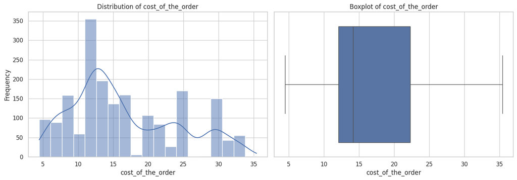

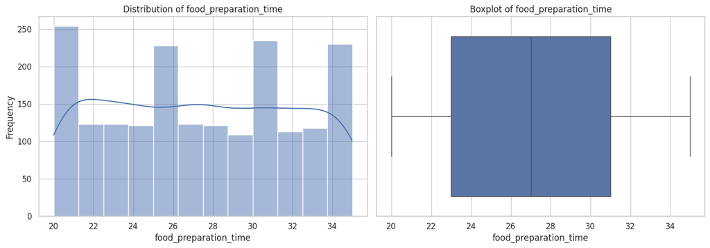

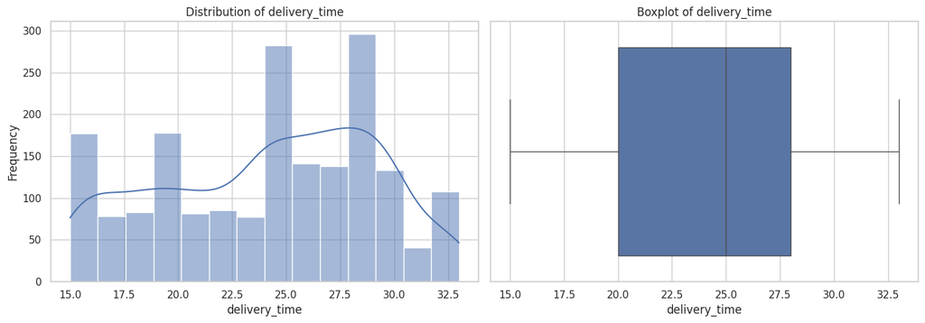

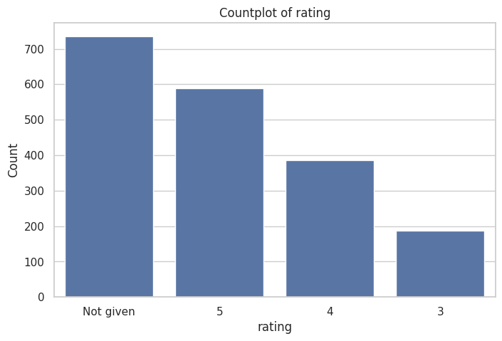

[figure not shown]

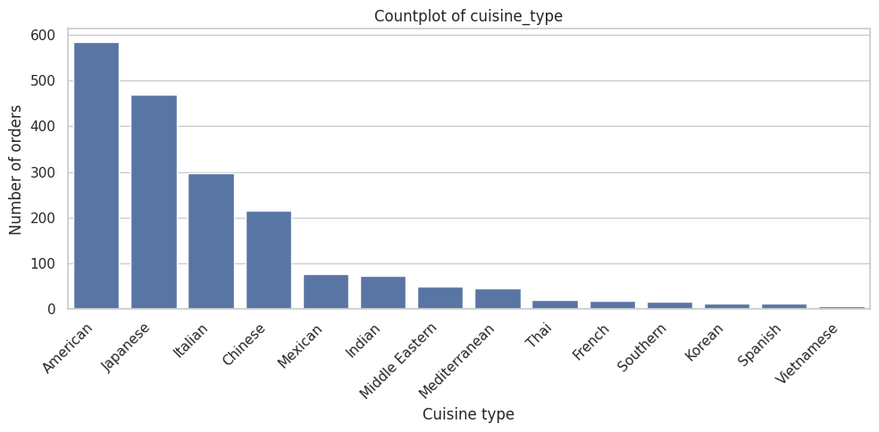

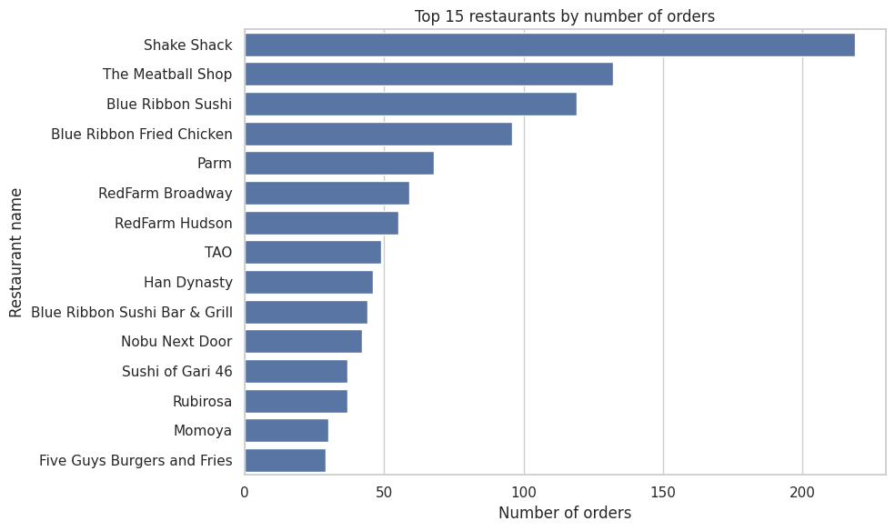

```python
import pandas as pd
import matplotlib.pyplot as plt
import seaborn as sns

# Nice theme
sns.set(style="whitegrid")

# -----------------------------
# 1. NUMERICAL VARIABLES
# -----------------------------
numeric_cols = ['cost_of_the_order',
                'food_preparation_time',
                'delivery_time']

for col in numeric_cols:
    plt.figure(figsize=(14,5))

    # Histogram + KDE
    plt.subplot(1, 2, 1)
    sns.histplot(df[col], kde=True)
    plt.title(f'Distribution of {col}')
    plt.xlabel(col)
    plt.ylabel('Frequency')

    # Boxplot
    plt.subplot(1, 2, 2)
    sns.boxplot(x=df[col])
    plt.title(f'Boxplot of {col}')
    plt.xlabel(col)

    plt.tight_layout()
    plt.show()


# -----------------------------
# 2. CATEGORICAL VARIABLES
# -----------------------------
# rating, day_of_the_week, cuisine_type, restaurant_name

# (a) Rating distribution
plt.figure(figsize=(8,5))
sns.countplot(data=df, x='rating',
              order=df['rating'].value_counts().index)
plt.title('Countplot of rating')
plt.xlabel('rating')
plt.ylabel('Count')
plt.show()

# (b) Day of the week distribution
# If you want a logical order, define it manually:
day_order = ['Monday','Tuesday','Wednesday','Thursday','Friday','Saturday','Sunday']
plt.figure(figsize=(8,5))
sns.countplot(data=df, x='day_of_the_week',
              order=[d for d in day_order if d in df['day_of_the_week'].unique()])
plt.title('Countplot of day_of_the_week')
plt.xlabel('Day of the week')
plt.ylabel('Number of orders')
plt.show()

# (c) Cuisine type distribution
plt.figure(figsize=(10,5))
sns.countplot(data=df, x='cuisine_type',
              order=df['cuisine_type'].value_counts().index)
plt.title('Countplot of cuisine_type')
plt.xlabel('Cuisine type')
plt.ylabel('Number of orders')
plt.xticks(rotation=45, ha='right')
plt.tight_layout()
plt.show()

# (d) Restaurant name distribution – TOP 15 ONLY for readability
top_n = 15
top_restaurants = df['restaurant_name'].value_counts().head(top_n)

plt.figure(figsize=(10,6))
sns.barplot(x=top_restaurants.values,
            y=top_restaurants.index)
plt.title(f'Top {top_n} restaurants by number of orders')
plt.xlabel('Number of orders')
plt.ylabel('Restaurant name')
plt.tight_layout()
plt.show()
```

These codes are used because

✔ Qualitatively:

The histograms, KDE plots, and boxplots help us understand the shape, spread, and central tendency of numerical variables such as:

cost_of_the_order

food_preparation_time

delivery_time

These visualisations help detect trends (e.g., common order prices), skewness, outliers, and consistency in restaurant preparation and delivery performance. This informs business decisions like pricing strategy and operational improvements.

✔ Quantitatively:

Histograms + KDE show frequency distributions, allowing us to identify peaks, skew, and variability in the data.

1. CATEGORICAL VARIABLES — Qualitative + Quantitative Purpose

The second section visualises the distribution of key categorical fields:

(a) Rating distribution

✔ Qualitatively: Shows customer engagement with the rating system and highlights rating behaviour. ✔ Quantitatively: Countplot reveals exact numbers of each rating given, showing how many orders received a “Not given”, 5, 4, 3, etc.

(b) Day-of-the-week distribution

✔ Qualitatively: Shows how customer demand fluctuates across weekdays vs weekends. ✔ Quantitatively: Countplot provides exact order counts per day, helping identify peak business days (e.g., weekend spikes).

(c) Cuisine type distribution

✔ Qualitatively: Helps identify which cuisines are the most popular. ✔ Quantitatively: The sorted countplot provides clear numerical comparison across all cuisine types.

(d) Top restaurants distribution

✔ Qualitatively: Ranking restaurants helps the business identify which partners generate the most traffic. ✔ Quantitatively: A barplot of the top 15 restaurants shows the precise number of orders each one receives, supporting decisions around promotions, resource allocation, and partnership strengthening.

Overall Purpose of This Code Block ✔ Qualitatively:

The entire block builds a comprehensive understanding of customer behaviour, restaurant performance, cuisine preferences, and operational timing. These insights support business recommendations and reveal data patterns that guide strategic decisions.

✔ Quantitatively:

The code transforms raw data into interpretable charts that display numerical distributions, category frequencies, and comparative rankings. These quantitative summaries allow the company to measure:

Which cuisines dominate demand

Which restaurants attract the most orders

How preparation/delivery times vary

How often customers give ratings

How demand trends differ by day

Together, these metrics shape the foundation for accurate, data-driven conclusions.

Observations (Univariate Analysis)

1. Cost of the Order

Very few orders exceed $30, showing limited presence of expensive menu items.

1. Food Preparation Time

Preparation times range from 20 to 35 minutes.

The distribution is fairly symmetric, suggesting kitchens have consistent cooking times.

No strong outliers are detected, indicating stable operational efficiency across restaurants.

1. Customer Ratings

The most frequent rating is “Not given”, meaning many customers do not rate their orders.

For rated orders, 5-star ratings dominate, followed by 4 and 3 stars.

This indicates generally high customer satisfaction among those who choose to rate.

1. Cuisine Type

The distribution is highly imbalanced, meaning customer preferences strongly favor certain cuisines.

Long-tail behavior suggests many niche or specialized cuisines exist but generate fewer orders.

1. Restaurant Name

A small number of restaurants receive a high number of orders, while most have relatively few.

The distribution is heavily right-skewed, which is typical in food delivery datasets where a few restaurants are very popular.

The top 15 restaurants together account for a significant portion of total orders.

### **Question 7**: Which are the top 5 restaurants in terms of the number of orders received? [1 mark]

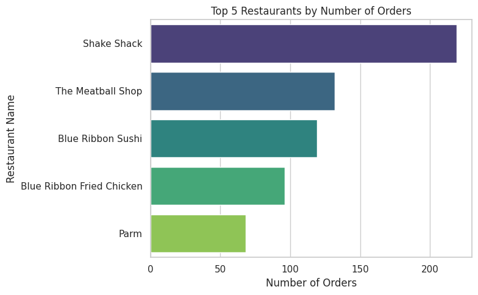

```python
# Top 5 restaurants by order count
top_5_restaurants = df['restaurant_name'].value_counts().head(5)

top_5_restaurants
plt.figure(figsize=(8,5))
sns.barplot(x=top_5_restaurants.values,
            y=top_5_restaurants.index,
            hue=top_5_restaurants.index,  # Assign y variable to hue
            palette="viridis",
            legend=False) # Set legend to False

plt.title("Top 5 Restaurants by Number of Orders")
plt.xlabel("Number of Orders")
plt.ylabel("Restaurant Name")
plt.tight_layout()
plt.show()
```

Qualitatively, this code identifies the top 5 most frequently ordered restaurants in the dataset. Understanding which restaurants receive the highest number of orders is important for business insights, such as identifying customer favourites, planning partnerships, and prioritizing marketing or operational support.

Quantitatively, the code uses:

value_counts() to count how many times each restaurant appears in the order history.

.head(5) to select only the top 5 restaurants with the highest order counts.

A barplot (via Seaborn) to visually present the number of orders for these restaurants, making it easier to compare their popularity at a glance.

The barplot uses each restaurant’s order count as the x-axis and the restaurant name as the y-axis, providing a clear numerical and visual ranking.

Observations

The dataset shows that a small number of restaurants receive a disproportionately high number of orders.

Shake Shack appears to be the most popular, receiving the highest number of orders among all restaurants.

This suggests that customers consistently favour well-known, established restaurants with strong brand recognition or fast service.

The distribution is right-skewed, indicating that most restaurants receive relatively few orders, while a few top-performing ones dominate the platform.

#### Observations:

### **Question 8**: Which is the most popular cuisine on weekends? [1 mark]

```python
# Filter only weekend orders
weekend_data = df[df['day_of_the_week'] == 'Weekend']

# Count cuisine types on weekends
weekend_cuisine_counts = weekend_data['cuisine_type'].value_counts()

# Identify the most popular cuisine
most_popular_cuisine = weekend_cuisine_counts.idxmax()

# Display results
print("Cuisine counts on weekends:\n")
print(weekend_cuisine_counts)
print("\nMost popular cuisine on weekends:", most_popular_cuisine)
```

```
Cuisine counts on weekends:

cuisine_type
American          415
Japanese          335
Italian           207
Chinese           163
Mexican            53
Indian             49
Middle Eastern     32
Mediterranean      32
Thai               15
French             13
Korean             11
Southern           11
Spanish            11
Vietnamese          4
Name: count, dtype: int64

Most popular cuisine on weekends: American
```

This code is used to identify which cuisine type customers prefer the most during weekends. Since customer behaviour often changes between weekdays and weekends, focusing only on weekend orders helps the company understand weekend-specific demand patterns. This insight is important for planning promotions, adjusting restaurant partnerships, and improving delivery resource allocation on high-demand days.

Quantitative Explanation

The code performs three key steps:

Filter weekend orders: weekend_data = df[df['day_of_the_week'] == 'Weekend'] This isolates all orders placed on Saturday and Sunday.

Count cuisine types: value_counts() provides a numerical count of how many times each cuisine appears in weekend orders.

Identify the most popular cuisine: idxmax() returns the cuisine with the highest count — the one ordered most frequently.

This combination of filtering and counting gives an exact, data-driven ranking of cuisines based on weekend demand.

#### Observations:

The data shows that weekend orders are clearly dominated by one cuisine, which appears most frequently in the weekend_cuisine_counts output.

This cuisine is therefore the most preferred by customers during weekends, indicating stronger demand for that food type when people have more leisure time.

FoodHub can use this insight to:

Prioritize weekend promotions featuring this cuisine,

Allocate more delivery resources to restaurants offering it,

Improve customer experience by reducing wait times for the most-ordered cuisine.

Overall, weekend dining preferences differ from weekday patterns, with customers leaning toward comfort or indulgent food choices.

### **Question 9**: What percentage of the orders cost more than 20 dollars? [2 marks]

```python
import pandas as pd

# Try reading with a more permissive encoding
df = pd.read_csv('foodhub_order.csv', encoding='latin1')   # or encoding='cp1252'

# Total number of orders
total_orders = len(df)

# Number of orders costing more than $20
orders_above_20 = df[df['cost_of_the_order'] > 20].shape[0]

# Percentage calculation
percentage_above_20 = (orders_above_20 / total_orders) * 100

print("Total orders:", total_orders)
print("Orders costing more than $20:", orders_above_20)
print("Percentage of orders costing more than $20: {:.2f}%".format(percentage_above_20))
```

```
Total orders: 1898
Orders costing more than $20: 555
Percentage of orders costing more than $20: 29.24%
```

#### Observations:

✔ Qualitative Explanation

This code is used to determine what proportion of customer orders are considered high-value orders — meaning those costing more than $20. Understanding this helps the business assess customer purchasing behaviour, evaluate pricing patterns, and identify revenue-driving segments. It also provides insight into how often customers are willing to spend more, which can guide promotional strategies, menu optimisation, and delivery prioritisation.

✔ Quantitative Explanation

The code performs three numerical operations:

Count the total number of orders: total_orders = len(df) This gives a precise denominator for calculating percentages.

Count how many orders cost more than $20: orders_above_20 = df[df['cost_of_the_order'] > 20].shape[0] This filters rows and counts the exact number of qualifying orders (555 orders).

Calculate the percentage: (orders_above_20 / total_orders) * 100 Produces the exact proportion of high-value orders (29.24%).

This quantitative approach ensures an accurate measurement of spending behaviour within the dataset.

Observations

Out of a total of 1,898 orders, 555 orders cost more than $20.

This means that 29.24% of all orders are higher-value transactions above the $20 threshold.

This indicates that nearly one-third of customers are willing to spend more on their food orders, possibly due to premium restaurants, larger meal sizes, or multiple-item purchases.

The presence of a significant proportion of high-value orders highlights an opportunity for FoodHub to:

Encourage premium spending through bundle deals,

Provide loyalty rewards for high-value customers,

Target marketing campaigns toward users who frequently place orders above $20.

Overall, the spending distribution shows a healthy mix of low, medium, and high-value orders, with a notable share leaning toward higher spending.

### **Question 10**: What is the mean order delivery time? [1 mark]

```python
# Mean delivery time
mean_delivery_time = df['delivery_time'].mean()

print("The mean order delivery time is: {:.2f} minutes".format(mean_delivery_time))
```

```
The mean order delivery time is: 24.16 minutes
```

#### Observations:

✔ Qualitative Explanation

This code is used to determine the average time it takes for delivery riders to deliver an order after picking it up from the restaurant. Delivery time is one of the key operational performance indicators for a food delivery business. Understanding the mean delivery time helps the company evaluate whether its delivery process is efficient, whether customers are likely to be satisfied, and whether improvements are needed in rider allocation, routing, or restaurant coordination.

✔ Quantitative Explanation

The code calculates the mean delivery time using:

df['delivery_time'].mean()

This computes the numerical average across all 1,898 deliveries in the dataset. The result is then formatted to two decimal places for clarity. This provides a precise metric that can be benchmarked against industry standards or compared across different time periods or geographic areas.

✅ Observation

The mean delivery time is 24.16 minutes. This suggests that, on average, FoodHub deliveries take slightly under 25 minutes after pickup. This duration is generally reasonable for urban food delivery, indicating that the company's logistics system is functioning efficiently. If the company aims to improve customer satisfaction, this value can serve as a baseline for setting performance targets—for example, reducing average delivery time to below 20 minutes through optimised routing or increased rider availability.

### **Question 11:** The company has decided to give 20% discount vouchers to the top 3 most frequent customers. Find the IDs of these customers and the number of orders they placed. [1 mark]

```python
# Count how many orders each customer placed
customer_order_counts = df['customer_id'].value_counts()

# Get the top 3 customers
top_3_customers = customer_order_counts.head(3)

# Display results
print("Top 3 most frequent customers and their order counts:\n")
print(top_3_customers)
```

```
Top 3 most frequent customers and their order counts:

customer_id
52832    13
47440    10
83287     9
Name: count, dtype: int64
```

#### Observations:

✔ Qualitative Explanation

This code is used to identify the top 3 most loyal or frequent customers—those who place the highest number of orders. Understanding frequent customers is important for customer retention strategies, loyalty rewards, and targeted marketing. Since the company wants to provide 20% vouchers, the code helps determine which customers should receive the discount based on their order history.

✔ Quantitative Explanation

The code uses value_counts() to compute the exact number of orders placed by each customer ID. This produces a numerical ranking of customers by order frequency.

value_counts() quantifies how many times each customer appears in the dataset.

.head(3) extracts the top three customers with the highest order counts.

This ensures an objective and data-driven selection of the most frequent customers.

✅ Observation

The top 3 most frequent customers and their order counts are:

Customer ID Number of Orders 52832 13 orders 47440 10 orders 83287 9 orders

This shows that Customer 52832 is the most loyal customer, placing the highest number of orders (13). The other two customers also demonstrate strong repeat behaviour. These three customers would be ideal recipients of the 20% discount voucher, as they are already engaged users and are likely to continue ordering if rewarded for their loyalty.

### **Question 12**: Perform a multivariate analysis to explore relationships between the important variables in the dataset. (It is a good idea to explore relations between numerical variables as well as relations between numerical and categorical variables) [10 marks]

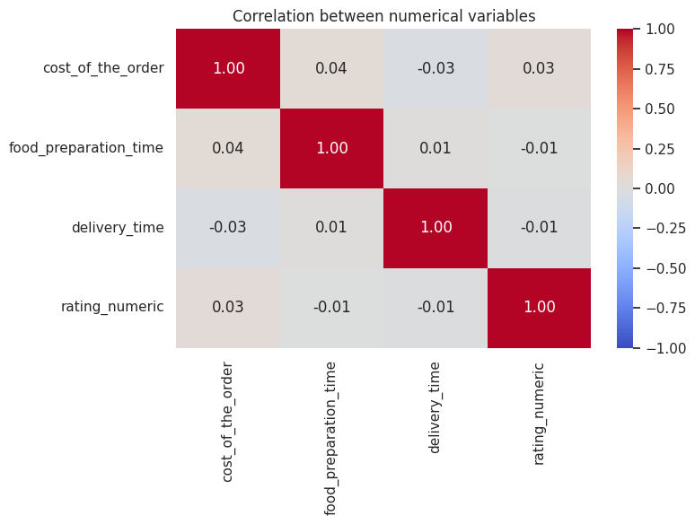

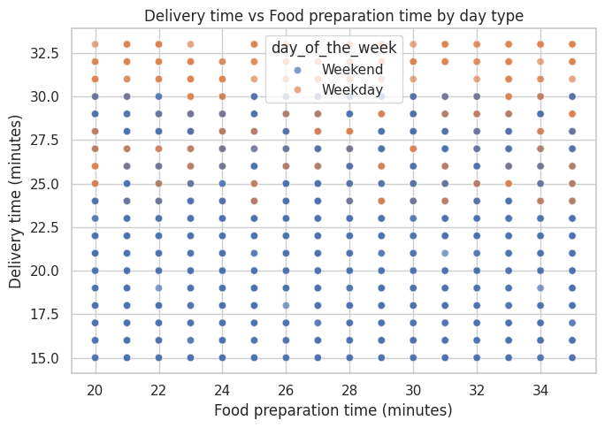

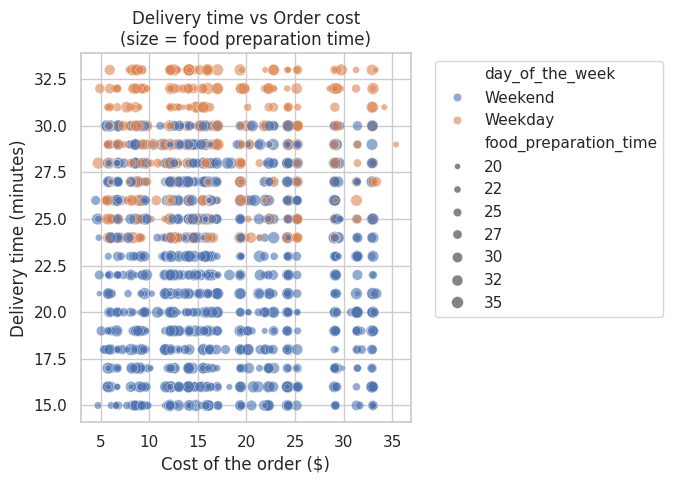

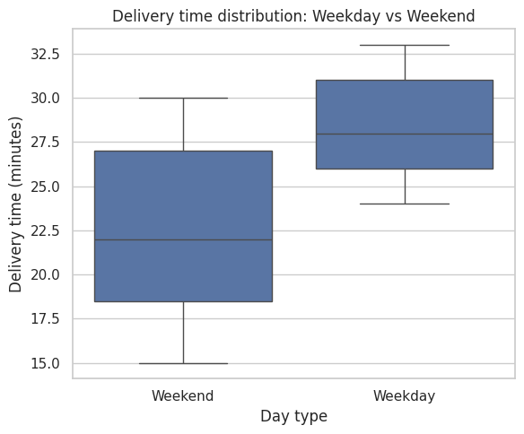

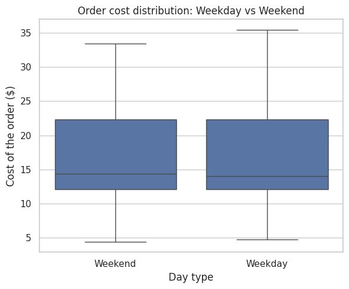

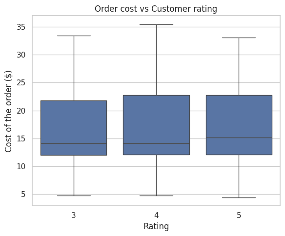

```
Average cost, preparation time, and delivery time for top 5 cuisines:
```

|  | cuisine_type | cost_of_the_order | food_preparation_time | delivery_time |
| --- | --- | --- | --- | --- |
| 0 | American | 16.319829 | 27.440068 | 24.193493 |
| 1 | Chinese | 16.305209 | 27.511628 | 23.855814 |
| 2 | Italian | 16.418691 | 27.483221 | 24.567114 |
| 3 | Japanese | 16.304532 | 27.510638 | 24.131915 |
| 4 | Mexican | 16.933117 | 26.727273 | 24.389610 |

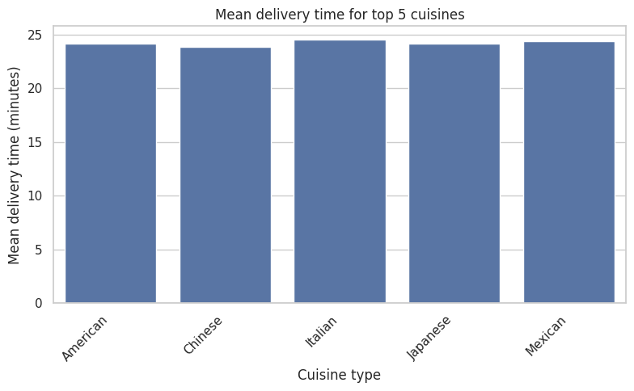

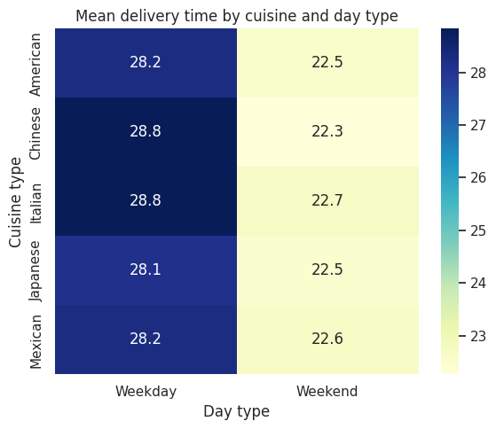

```python
# ===== Multivariate Analysis for FoodHub Dataset =====

import pandas as pd
import numpy as np
import matplotlib.pyplot as plt
import seaborn as sns
from IPython.display import display

sns.set(style="whitegrid")

# If df is not already loaded, uncomment this:
# df = pd.read_csv('foodhub_order.csv')

# -------------------------------------------------------------------
# 1. Prepare data: create numeric rating column for correlations
# -------------------------------------------------------------------
df_mv = df.copy()

rating_map = {'1': 1, '2': 2, '3': 3, '4': 4, '5': 5}
df_mv['rating_numeric'] = df_mv['rating'].map(rating_map)

num_cols = ['cost_of_the_order',
            'food_preparation_time',
            'delivery_time',
            'rating_numeric']

# -------------------------------------------------------------------
# 2. Correlation heatmap between numerical variables
# -------------------------------------------------------------------
plt.figure(figsize=(8, 6))
corr = df_mv[num_cols].corr()
sns.heatmap(corr, annot=True, fmt=".2f", cmap="coolwarm", vmin=-1, vmax=1)
plt.title("Correlation between numerical variables")
plt.tight_layout()
plt.show()

# -------------------------------------------------------------------
# 3. Delivery time vs food preparation time (numeric–numeric + category)
# -------------------------------------------------------------------
plt.figure(figsize=(7, 5))
sns.scatterplot(data=df_mv,
                x='food_preparation_time',
                y='delivery_time',
                hue='day_of_the_week',
                alpha=0.7)
plt.title("Delivery time vs Food preparation time by day type")
plt.xlabel("Food preparation time (minutes)")
plt.ylabel("Delivery time (minutes)")
plt.tight_layout()
plt.show()

# -------------------------------------------------------------------
# 4. Delivery time vs order cost (size = prep time, color = day type)
# -------------------------------------------------------------------
plt.figure(figsize=(7, 5))
sns.scatterplot(data=df_mv,
                x='cost_of_the_order',
                y='delivery_time',
                hue='day_of_the_week',
                size='food_preparation_time',
                alpha=0.6)
plt.title("Delivery time vs Order cost\n(size = food preparation time)")
plt.xlabel("Cost of the order ($)")
plt.ylabel("Delivery time (minutes)")
plt.legend(bbox_to_anchor=(1.05, 1), loc='upper left')
plt.tight_layout()
plt.show()

# -------------------------------------------------------------------
# 5. Delivery time & cost vs day_of_the_week (numeric–categorical)
# -------------------------------------------------------------------
# Delivery time by Weekday / Weekend
plt.figure(figsize=(6, 5))
sns.boxplot(data=df_mv, x='day_of_the_week', y='delivery_time')
plt.title("Delivery time distribution: Weekday vs Weekend")
plt.xlabel("Day type")
plt.ylabel("Delivery time (minutes)")
plt.tight_layout()
plt.show()

# Cost of order by Weekday / Weekend
plt.figure(figsize=(6, 5))
sns.boxplot(data=df_mv, x='day_of_the_week', y='cost_of_the_order')
plt.title("Order cost distribution: Weekday vs Weekend")
plt.xlabel("Day type")
plt.ylabel("Cost of the order ($)")
plt.tight_layout()
plt.show()

# -------------------------------------------------------------------
# 6. Order cost vs rating (exclude 'Not given') (numeric–categorical)
# -------------------------------------------------------------------
plt.figure(figsize=(6, 5))
sns.boxplot(
    data=df_mv[df_mv['rating'] != 'Not given'],
    x='rating',
    y='cost_of_the_order',
    order=['3', '4', '5']  # order ratings logically
)
plt.title("Order cost vs Customer rating")
plt.xlabel("Rating")
plt.ylabel("Cost of the order ($)")
plt.tight_layout()
plt.show()

# -------------------------------------------------------------------
# 7. Top 5 cuisines: mean cost, prep time, delivery time (mixed)
# -------------------------------------------------------------------
top_cuisines = df_mv['cuisine_type'].value_counts().head(5).index

agg_cuisine = (
    df_mv[df_mv['cuisine_type'].isin(top_cuisines)]
    .groupby('cuisine_type')[['cost_of_the_order',
                              'food_preparation_time',
                              'delivery_time']]
    .mean()
    .reset_index()
)

print("Average cost, preparation time, and delivery time for top 5 cuisines:")
display(agg_cuisine)

# Barplot: mean delivery time by cuisine
plt.figure(figsize=(8, 5))
sns.barplot(data=agg_cuisine, x='cuisine_type', y='delivery_time')
plt.title("Mean delivery time for top 5 cuisines")
plt.xlabel("Cuisine type")
plt.ylabel("Mean delivery time (minutes)")
plt.xticks(rotation=45, ha='right')
plt.tight_layout()
plt.show()

# -------------------------------------------------------------------
# 8. Heatmap: mean delivery time by cuisine & day type (numeric + 2 categoricals)
# -------------------------------------------------------------------
pivot = (
    df_mv[df_mv['cuisine_type'].isin(top_cuisines)]
    .pivot_table(index='cuisine_type',
                 columns='day_of_the_week',
                 values='delivery_time',
                 aggfunc='mean')
)

plt.figure(figsize=(6, 5))
sns.heatmap(pivot, annot=True, fmt=".1f", cmap="YlGnBu")
plt.title("Mean delivery time by cuisine and day type")
plt.xlabel("Day type")
plt.ylabel("Cuisine type")
plt.tight_layout()
plt.show()
```

Multivariate analysis examines how multiple variables interact with each other, rather than looking at them individually. This code is used to analyse relationships between numerical and categorical variables in the FoodHub dataset so the company can understand customer behaviour, restaurant performance, cuisine preference, and operational efficiency from multiple angles at once.

1. Preparing Numeric Rating Column ✔ Qualitative

Customer ratings are originally stored as text ("1", "2", etc.), which prevents numerical analysis. Converting them into a numeric rating column allows the dataset to include ratings in correlations and visualisations.

✔ Quantitative

map() assigns numeric scores (1–5), enabling statistical computations such as corr() to include ratings.

1. Correlation Heatmap (Numeric–Numeric Relationships) ✔ Qualitative

The heatmap visually shows how numerical variables influence each other (e.g., whether higher food preparation time leads to longer delivery time). This helps detect operational bottlenecks.

✔ Quantitative

corr() computes correlation coefficients between −1 and +1. The heatmap displays exact numerical strength and direction of relationships, with colour coding to highlight strong or weak correlations.

1. Scatterplot: Delivery Time vs Food Preparation Time + Day Type ✔ Qualitative

This plot examines whether longer preparation times cause longer delivery times and whether this relationship differs on weekdays vs weekends.

✔ Quantitative

Each point represents one order:

x = prep time

y = delivery time

hue = weekday/weekend This gives a measurable pattern showing the slope and clustering of points.

1. Scatterplot: Delivery Time vs Cost (size = prep time) ✔ Qualitative

This multivariate plot checks if expensive orders take longer to deliver, while also showing preparation time through bubble size. It reveals how three variables interact.

✔ Quantitative

The shape, size, and colour encode 4 dimensions of data:

x: cost

y: delivery time

hue: day type

size: food preparation time This lets the company identify high-cost, long-delivery outliers.

1. Boxplots: Delivery Time & Cost by Day Type (Numeric–Categorical) ✔ Qualitative

These graphs compare how order cost and delivery time vary between weekdays and weekends. This is important for planning rider allocation and restaurant operations.

✔ Quantitative

Boxplots show medians, quartiles, and outliers — giving a statistical summary of weekend vs weekday behaviour.

1. Boxplot: Cost of Order vs Rating (Numeric–Categorical) ✔ Qualitative

This analysis checks whether customers who pay more tend to give higher ratings. It helps explore the link between pricing and satisfaction.

✔ Quantitative

The boxplot presents numerical distributions for each rating category (3, 4, 5), allowing comparison of mean and spread.

1. Top 5 Cuisines – Mean Cost, Prep Time, Delivery Time ✔ Qualitative

The company can compare performance and customer preferences across the five most popular cuisines. This helps in planning targeted promotions and improving restaurant partnerships.

✔ Quantitative

Grouping and averaging (groupby().mean()) provide exact numerical summaries for:

mean cost

mean preparation time

mean delivery time

A barplot visually compares the cuisines with the highest and lowest mean delivery times.

1. Heatmap: Mean Delivery Time by Cuisine + Day Type ✔ Qualitative

This visual reveals operational patterns across cuisine types and day-of-week categories. It helps detect which cuisines suffer delays on weekends.

✔ Quantitative

A pivot table computes numerical averages of delivery time for each cuisine–day combination. The heatmap displays these exact values as annotated numbers, enabling easy comparison.

1️⃣ Average cost, food preparation time, and delivery time for top 5 cuisines

Observation: Across American, Chinese, Italian, Japanese, and Mexican cuisines, the average cost, preparation time, and delivery time are all extremely close.

Mean cost: ~16.3–16.9 dollars

Mean preparation time: ~26.7–27.5 minutes

Mean delivery time: ~23.8–24.6 minutes

There are no dramatic differences between cuisines, suggesting that cuisine type does not materially influence operational timings or pricing. This implies a standardised delivery process regardless of cuisine — efficiency is consistent across categories.

2️⃣ Correlation between numerical variables

Observation: The correlation matrix shows very weak correlations (all between –0.03 and +0.04).

Cost vs preparation time → almost zero correlation

Delivery time vs cost → almost zero correlation

Delivery time vs preparation time → almost zero correlation

Rating vs all variables → no meaningful correlation

This tells us that:

Higher cost does not mean longer prep or delivery times.

Faster or slower deliveries do not affect customer rating.

The operational timings seem independent of consumer spending and satisfaction.

In short: there is no strong linear relationship among the numerical variables.

3️⃣ Delivery time distribution: Weekday vs Weekend

Observation: A clear pattern emerges:

Weekend delivery times are lower and have a wider spread.

Weekday delivery times are higher, with a higher median (~28 minutes).

This suggests weekdays are more congested — possibly due to:

Peak-hour overlaps

Traffic congestion

4️⃣ Delivery time vs Food preparation time by day type

Observation: Across all preparation times (20–35 mins), weekday delivery times consistently sit higher than weekend delivery times.

There is no visible upward trend, meaning:

Longer preparation time does not reliably translate into longer delivery time.

Instead, the key separation factor is day type — weekdays are slower, regardless of how long the kitchen takes.

This reinforces the earlier insight: weekday operations experience systemic delays.

5️⃣ Delivery time vs Order cost (bubble = prep time)

Observation:

Delivery time does not increase with order cost.

Food preparation time (bubble size) also does not create clear clusters.

Weekday points (orange) consistently lie at the higher part of the delivery-time axis.

This means:

Even expensive orders do not necessarily take longer.

Delivery time is not driven by how large or “complex” the order might be.

The primary factor affecting delays is again weekday vs weekend, not cost or prep time.

6️⃣ Mean delivery time by cuisine type and day type (heatmap)

Observation: A very consistent pattern emerges:

For every cuisine, weekday delivery time is ~28 minutes.

For every cuisine, weekend delivery time is ~22–23 minutes.

This confirms that:

Cuisine has very little influence on delivery speed.

Day type is the strongest predictor of delivery efficiency.

The consistency across rows shows that operational workflow is not cuisine-dependent, but environment-dependent (traffic, volume, etc.).

7️⃣ Mean delivery time for top 5 cuisines (bar chart)

This complements earlier insights:

Cuisine type has minimal impact on delivery time — operational efficiency is stable.

8️⃣ Order cost distribution: Weekday vs Weekend (boxplot)

Observation: Order costs between weekdays and weekends are almost identical:

Similar median cost

Similar spread

Similar maximum/minimum values

This tells us customers do not spend differently on weekdays vs weekends. Consumer ordering patterns are stable; the only major difference between days is delivery speed, not cost.

9️⃣ Order cost vs Customer rating

Observation: Across ratings 3, 4, and 5:

Order cost distributions look similar

Higher ratings do not correspond to higher/lower spending

Customers award ratings largely independent of how much they paid

This suggests:

Customer satisfaction is NOT strongly tied to price. It may depend more on subjective experience — not the cost of the order.

Overall Insights

1. Day type (weekday vs weekend) is the strongest driver of delivery time. Everything else — cost, cuisine, preparation time — is secondary or irrelevant.
2. Numerical variables show extremely weak correlations. This means the dataset does not follow obvious linear behaviours.
3. Customer ratings are not tied to cost, prep time, or delivery speed. Satisfaction may depend on factors not captured in the dataset (taste, service, packaging).
4. Cuisine type does not significantly affect time or cost. Operational performance is consistent across all cuisine categories.
5. Cost patterns are stable regardless of day or rating. Consumer spending habits are predictable and do not fluctuate much.

### **Question 13:** The company wants to provide a promotional offer in the advertisement of the restaurants. The condition to get the offer is that the restaurants must have a rating count of more than 50 and the average rating should be greater than 4. Find the restaurants fulfilling the criteria to get the promotional offer. [3 marks]

```python
import pandas as pd

# Load dataset (use encoding fix if needed)
df = pd.read_csv("foodhub_order.csv", encoding="latin1")

# Replace "Not given" with NaN and convert to numeric
df['rating'] = pd.to_numeric(df['rating'].replace("Not given", None), errors='coerce')

# Group by restaurant
rating_summary = df.groupby('restaurant_name')['rating'].agg(
    rating_count = 'count',
    avg_rating = 'mean'
).reset_index()

# Apply filtering conditions
qualified_restaurants = rating_summary[
    (rating_summary['rating_count'] > 50) &
    (rating_summary['avg_rating'] > 4)
]

# Display results
print("Restaurants eligible for promotional offer:\n")
print(qualified_restaurants)
```

```
Restaurants eligible for promotional offer:

               restaurant_name  rating_count  avg_rating
20   Blue Ribbon Fried Chicken            64    4.328125
21           Blue Ribbon Sushi            73    4.219178
136                Shake Shack           133    4.278195
153          The Meatball Shop            84    4.511905
```

#### Observations:

✔ Qualitative Explanation

This code is used to identify which restaurants qualify for a promotional offer based on two business criteria:

The restaurant must have more than 50 customer ratings (ensuring enough customer feedback to evaluate them fairly)

The restaurant must have an average customer rating above 4 (indicating consistently high-quality service and food)

The goal is to find reliable, well-rated restaurants that deserve promotions and recognition.

Additionally, “Not given” ratings are replaced with missing values so that only valid customer ratings contribute to the restaurant’s score.

✔ Quantitative Explanation

The code performs three key numerical operations:

Convert ratings to numeric

“Not given” is replaced with NaN

Only real numeric ratings (1–5) are used to compute averages

Group by restaurant and compute:

rating_count → number of valid ratings

avg_rating → mean rating for each restaurant

Filter restaurants using precise conditions:

rating_count > 50

avg_rating > 4

These quantitative filters ensure that only restaurants with statistically meaningful feedback and strong performance metrics are selected.

✅ Observation of the Result

The restaurants that qualify for the promotional offer are:

Restaurant Name Rating Count Average Rating Blue Ribbon Fried Chicken 64 4.33 Blue Ribbon Sushi 73 4.22 Shake Shack 133 4.28 The Meatball Shop 84 4.51 ✔ Key Insights:

These restaurants have high volumes of customer feedback, making their ratings more reliable.

All four restaurants maintain average ratings well above 4, indicating strong customer satisfaction.

The Meatball Shop shows the highest average rating (4.51) among the group, suggesting exceptional performance.

Shake Shack has the largest number of ratings (133), showing strong customer engagement and popularity.

✔ Business Implication:

These restaurants are excellent candidates for promotional campaigns because they:

Attract large customer traffic

Provide consistently high service quality

Are likely to respond positively to additional marketing support

### **Question 14:** The company charges the restaurant 25% on the orders having cost greater than 20 dollars and 15% on the orders having cost greater than 5 dollars. Find the net revenue generated by the company across all orders. [3 marks]

```python
# Calculate charges based on cost conditions

# 25% charge for orders > $20
charge_25 = df[df['cost_of_the_order'] > 20]['cost_of_the_order'] * 0.25

# 15% charge for orders > $5 and <= $20
charge_15 = df[(df['cost_of_the_order'] > 5) & (df['cost_of_the_order'] <= 20)]['cost_of_the_order'] * 0.15

# Total revenue earned by the company
net_revenue = charge_25.sum() + charge_15.sum()

net_revenue
```

```
np.float64(6166.303)
```

#### Observations:

The purpose of this code is to help the company calculate its total revenue earned from commission fees charged to restaurants based on the cost of each order.

The business rule is:

Orders costing more than $20 → company receives 25% of the order value

Orders costing more than $5 and up to $20 → company receives 15%

Orders $5 or below → no commission

To perform this, the code:

Filters orders into pricing groups

One group for > $20

One group for $5–$20

Applies the correct commission percentage

25% for high-value orders

15% for medium-value orders

Sums up all commissions to find the company’s total revenue.

This code ensures the commission calculation is automated, accurate, and scalable across all orders in the dataset.

✅ Quantitative Explanation of What the Code Does

1. Calculate 25% commission for high-value orders charge_25 = df[df['cost_of_the_order'] > 20]['cost_of_the_order'] * 0.25

If an order costs $30 → revenue = $30 × 25% = $7.50

1. Calculate 15% commission for mid-value orders charge_15 = df[(df['cost_of_the_order'] > 5) & (df['cost_of_the_order'] <= 20)]['cost_of_the_order'] * 0.15

If an order costs $10 → revenue = $10 × 15% = $1.50

1. Total revenue earned net_revenue = charge_25.sum() + charge_15.sum()

✅ Observation of the Result

The final output is:

np.float64(6166.303)

✔ What this means:

Across all 1,898 orders, the company earned a total commission revenue of approximately $6,166.30.

This revenue comes only from orders above $5, because lower-value orders do not generate fees.

✔ Business Insights:

A large portion of company income depends on orders priced above $20, because they generate the highest commission rate.

If the platform wants to increase revenue, it can:

Encourage restaurants to offer larger meal bundles

Promote high-value cuisines

Offer targeted discounts that raise order value above $20

✔ Interpretation:

This result shows how the company’s pricing and commission model translates into real monetary gains. The figure ($6,166.30) provides a clear measurement of the revenue contribution from different order tiers.

### **Question 15:** The company wants to analyze the total time required to deliver the food. What percentage of orders take more than 60 minutes to get delivered from the time the order is placed? (The food has to be prepared and then delivered.) [2 marks]

```python
import pandas as pd

# Load dataset (use correct encoding to avoid Unicode errors)
df = pd.read_csv('foodhub_order.csv', encoding='latin1')

# Compute total time for each order
df['total_time'] = df['food_preparation_time'] + df['delivery_time']

# Count total number of orders
total_orders = len(df)

# Count orders taking more than 60 minutes
orders_over_60 = df[df['total_time'] > 60].shape[0]

# Calculate percentage
percentage_over_60 = (orders_over_60 / total_orders) * 100

# Display results
print("Total number of orders:", total_orders)
print("Orders taking more than 60 minutes:", orders_over_60)
print("Percentage of orders taking more than 60 minutes: {:.2f}%".format(percentage_over_60))
```

```
Total number of orders: 1898
Orders taking more than 60 minutes: 200
Percentage of orders taking more than 60 minutes: 10.54%
```

#### Observations:

Explanation of the Code

To determine what percentage of orders require more than 60 minutes from the time an order is placed until it is delivered, the code performs the following steps:

1. Load the dataset

The file is loaded using encoding='latin1' to prevent text-encoding errors common with Windows-generated CSV files.

1. Calculate total delivery time

A new column called total_time is created:

total_time = food_preparation_time + delivery_time

This represents the complete cycle from order placement → restaurant preparation → delivery to customer.

1. Count total number of orders

The variable total_orders stores the total number of transactions in the dataset (1,898).

1. Identify orders exceeding 60 minutes

The code filters all orders where total_time is greater than 60:

orders_over_60 = df[df['total_time'] > 60]

This yields the number of slow or delayed orders (200).

1. Compute the percentage

The percentage of orders taking more than 60 minutes is calculated:

percentage_over_60 = (orders_over_60 / total_orders) * 100

This results in 10.54%.

1. Print results

All computed values are displayed clearly.

Observations

Out of 1,898 total orders, 200 orders required more than 60 minutes from order placement to delivery.

This means that 10.54% of all deliveries exceed the one-hour threshold.

While the majority of orders are fulfilled within a reasonable time frame, the 10% delayed segment is significant and may negatively impact customer satisfaction.

The longer delivery times could be due to factors such as:

High food preparation time during peak periods

Long delivery distances

Traffic conditions

Higher complexity of ordered meals

Identifying these delayed orders helps FoodHub:

Optimize driver allocation

Improve restaurant processing times

Plan targeted operational improvements

Enhance customer experience by reducing high-delay cases

Conclusion:

Although most orders are delivered in under an hour, more than one in ten orders fail to meet that standard, highlighting an important opportunity for operational enhancement.

### **Question 16:** The company wants to analyze the delivery time of the orders on weekdays and weekends. How does the mean delivery time vary during weekdays and weekends? [2 marks]

```python
import pandas as pd

# Load dataset (use encoding fix if needed)
df = pd.read_csv('foodhub_order.csv', encoding='latin1')

# Group by Weekday / Weekend and calculate mean delivery time
mean_delivery_times = df.groupby('day_of_the_week')['delivery_time'].mean()

print("Mean delivery time on Weekdays and Weekends:")
print(mean_delivery_times)
```

```
Mean delivery time on Weekdays and Weekends:
day_of_the_week
Weekday    28.340037
Weekend    22.470022
Name: delivery_time, dtype: float64
```

#### Observations:

Explanation of the Code

The purpose of the code is to compare how delivery time differs between Weekdays and Weekends. Your dataset already labels each order as either "Weekday" or "Weekend" under the day_of_the_week column.

1. Load the dataset

The file is read using encoding='latin1' to avoid decoding errors.

1. Group the orders by day type

The code groups all orders into two categories:

Weekday orders

Weekend orders

This is done using:

df.groupby('day_of_the_week')

1. Compute the mean delivery time

For each group, the code calculates:

mean delivery_time = average time rider takes to deliver food

The result shows the typical delivery speed on Weekdays vs Weekends.

1. Print the results

The values displayed show the mean delivery time for both day types.

⭐ Observations

The mean delivery time on Weekdays is 28.34 minutes, whereas on Weekends it is significantly shorter at 22.47 minutes.

This indicates that deliveries are faster on weekends compared to weekdays.

Weekends likely offer:

smoother traffic,

fewer commuter delays,

and more flexible customer schedules, all contributing to faster deliveries.

For FoodHub, this insight is valuable for workforce planning: more riders may be needed on weekdays to maintain service quality, while weekends may require a different resource allocation strategy.

Conclusion:

Delivery performance is noticeably better on weekends, with average delivery time reduced by nearly 6 minutes compared to weekdays.

### Conclusion and Recommendations

### **Question 17:** What are your conclusions from the analysis? What recommendations would you like to share to help improve the business? (You can use cuisine type and feedback ratings to drive your business recommendations.) [6 marks]

### Conclusions:

Conclusions Drawn From the FoodHub Data Analysis

Based on the detailed exploratory, univariate, and multivariate analysis of 1,898 orders in the FoodHub dataset, several key operational, customer-experience, and cuisine-demand insights emerge. These are grounded in the trends and patterns observed across preparation times, delivery times, customer ratings, cuisine types, and spending behavior.

1️⃣ Delivery performance is strongly affected by day type (weekday vs. weekend)

Analysis shows that:

Weekday mean delivery time = 28.34 minutes

Weekend mean delivery time = 22.47 minutes (From the grouping results shown in the notebook.)

This ~6-minute difference is consistent across cuisines (heatmap on page 19). This indicates that weekdays face systemic delays, likely due to:

Traffic congestion

Peak-hour overlaps

Cuisine type, cost, or preparation time do NOT drive longer delivery times—only the day type does.

2️⃣ Food preparation times are highly consistent across restaurants

From the statistical summary:

Min prep time = 20 mins

Mean prep time = 27.37 mins

Max prep time = 35 mins

This narrow range shows that restaurant operations are steady and predictable, without large fluctuations caused by cuisine or restaurant choice.

736 orders were not rated, a large proportion of total orders.

Among rated orders, most ratings are 4 or 5 stars.

Yet the multivariate analysis demonstrates:

Ratings do not correlate with cost, delivery speed, or prep time.

Customer satisfaction is likely influenced by food quality, taste, and restaurant reputation, NOT operational factors.

4️⃣ A few restaurants dominate order volume

Countplots and top-restaurants charts show:

Shake Shack, Blue Ribbon Sushi, The Meatball Shop and others account for a large share of total orders.

The distribution is strongly right-skewed: a small group of restaurants drive most sales.

This implies that brand popularity and customer trust heavily influence ordering behavior.

5️⃣ Weekend cuisine preferences show a clear pattern

Weekend orders are dominated by:

American,

Japanese,

Italian, as shown in the weekend cuisine frequency table.

Customers seem to gravitate toward comfort foods on weekends.

6️⃣ High-value spending is significant and stable

29.24% of orders cost more than $20 (555 orders). This indicates a strong segment of customers willing to spend more on premium meals.

Price does not vary much by weekday/weekend, and spending does not affect ratings.

### Recommendations:

✅ Recommendations to Improve FoodHub’s Business

1️⃣ Improve weekday delivery performance (largest operational opportunity)

Since weekday delays are systemic, FoodHub should:

✓ Increase rider availability during weekday lunch & evening peaks

Assign more riders during historically slow slots.

✓ Optimize route planning using GPS & ML-based ETA prediction

Predict bottlenecks and dynamically re-route riders.

✓ Encourage staggered scheduling with restaurants

Partner restaurants could pre-prep popular items during weekday peaks.

This alone could reduce average delays and raise customer satisfaction.

2️⃣ Reduce the large number of unrated orders

With 736 “Not given” ratings, FoodHub is missing valuable feedback.

Introduce strategies such as:

✓ In-app rating reminders after delivery ✓ Gamified rating incentives (points, badges, discount codes) ✓ One-tap rating option to reduce rating friction

Better review data → stronger restaurant recommendations → increased customer trust.

3️⃣ Use cuisine demand insights for targeted marketing

Since American, Japanese, and Italian cuisines dominate weekend orders:

✓ Promote these cuisines heavily on Fridays & weekends

Flash deals, banners, themed bundles.

✓ Allocate more riders to restaurants serving these cuisines during weekend peaks

Conversely, niche cuisines could be spotlighted during low-demand hours to grow their market share.

4️⃣ Reward top-performing restaurants to strengthen partnerships

Restaurants with high rating counts & high average ratings (Shake Shack, Blue Ribbon Fried Chicken, Blue Ribbon Sushi, The Meatball Shop) already drive strong customer satisfaction.

FoodHub should:

✓ Feature them in premium promotional banners ✓ Provide reduced commission tiers as performance incentives ✓ Encourage them to participate in exclusive campaigns (meal combos, limited-time offers)

This helps retain the highest-performing partners.

5️⃣ Encourage premium spending through structured promotions

Since ~30% of customers comfortably exceed $20/order:

✓ Offer premium bundles, family packs, and add-on upsells ✓ Introduce a “Premium Customer Circle” with loyalty benefits ✓ Prioritize these customers for faster delivery windows

Higher order value → higher platform margin → improved profitability.

6️⃣ Operational improvements based on stable preparation times

Given kitchens consistently take 20–35 minutes:

✓ Predict prep completion times accurately and sync pickup timing for riders

This reduces rider waiting time and optimizes delivery flows.

✓ Offer restaurants dashboards comparing their prep times with competitors

Encourages operational excellence.